# PyRATES: Signal Processing (R Version)

Julien Emile-Geay, University of Southern California (Translated to R by Nick McKay and Claude.ai)

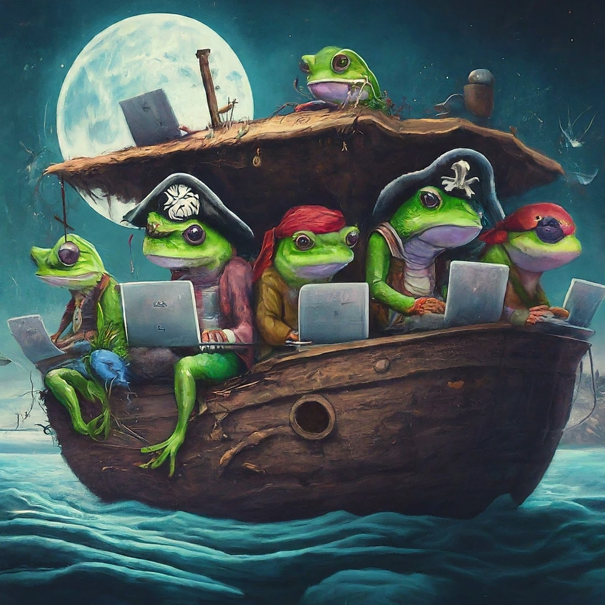

# Signal Processing in R

## Preamble

Often timeseries have to be treated prior to analysis. This is a delicate game: altering data is a cardinal sin, so one needs to be very aware of one’s doing prior to engaging in this activity. Here we show a few examples where such treatment may be warranted.

### Goals

- Become familiar with various filtering methods and some of their arguments
- Become familiar with various detrending methods and some of their arguments

**Reading Time: 20 min**

### Keywords

Filtering, Detrending.

### Pre-requisites

Some timeseries analysis, ideally

### Relevant Packages

signal, zoo, trend, Mcomp, Rssa, ggplot2

Let’s first load necessary packages:

```r
library(signal)
library(zoo)
library(trend)
library(Mcomp)
library(Rssa)
library(tidyverse)
```

## Filtering

The goal of filtering is to enhance part of a signal, or suppress one or more parts. We’ll use R’s `signal` package, which provides a variety of filters.

Let’s use data from a Hawai’i seismogram and isolate certain oscillations.

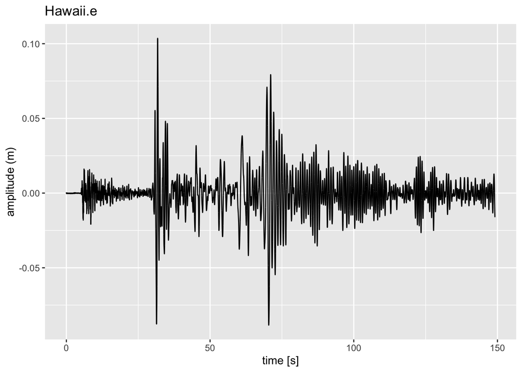

```r
df <- read.table('https://github.com/LinkedEarth/PyRATES_practicums_py/raw/main/jbook/data/hawaii.e.dat', col.names = c('time', 'ground_motion'))
df$time <- df$time / 1000
df$ground_motion <- df$ground_motion * 1000

ggplot(df, aes(x = time, y = ground_motion)) +
  geom_line() +
  labs(x = 'time [s]', y = 'amplitude (m)', title = 'Hawaii.e')
```

### Filter Types

First, let’s check if the data is evenly spaced:

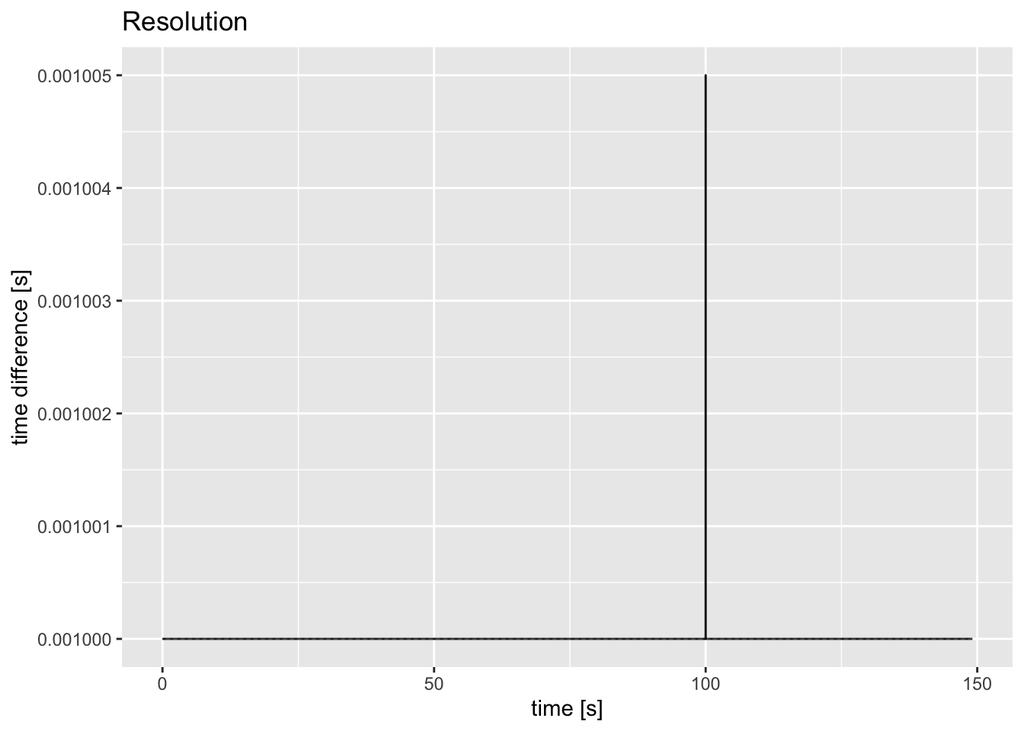

```r
diff_time <- data.frame(resolution= diff(df$time),
                        time = rowMeans(cbind(df$time[-1],df$time[-length(df$time)])))


#make a histogram of the options
ggplot(diff_time) +
  geom_line(aes(x = time,y = resolution)) +
  labs(x = 'time [s]', y = 'time difference [s]', title = 'Resolution')
```

It appears that the resolution jumps at around the 100th second. Let’s interpolate to get an even resolution of 1ms:

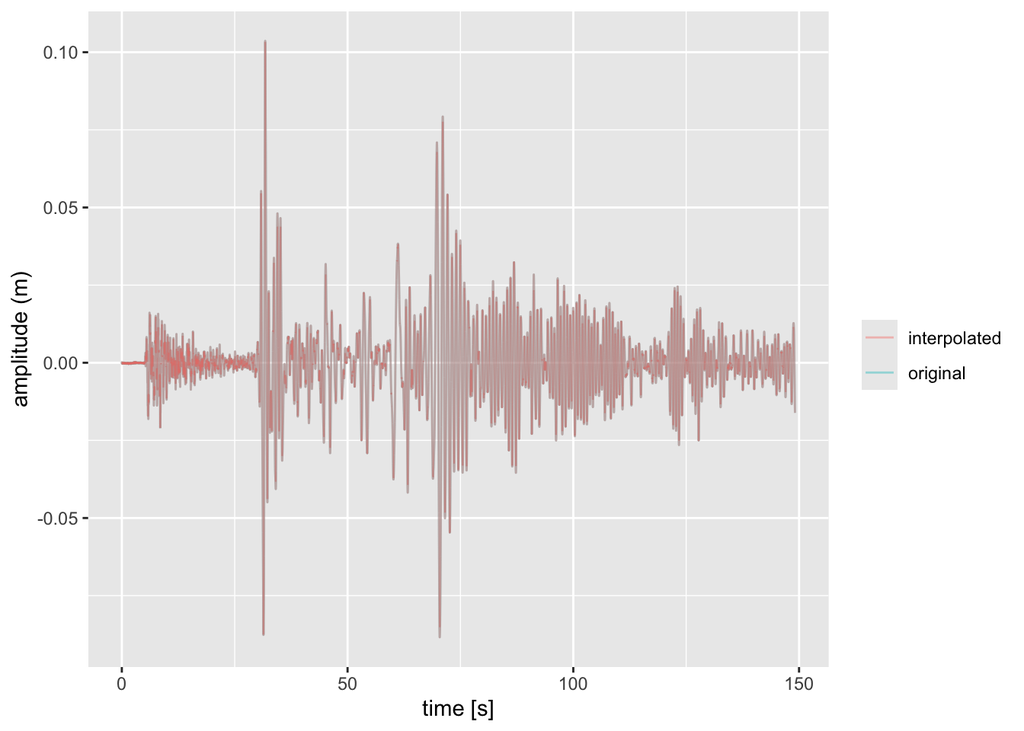

```r
ts <- zoo(df$ground_motion, df$time)
ts_interp <- na.approx(ts, xout = seq(min(df$time), max(df$time), by = 0.001))

ggplot() +
  geom_line(data = df, aes(x = time, y = ground_motion, color = 'original'), alpha = 0.4) +
  geom_line(data = data.frame(time = index(ts_interp), ground_motion = coredata(ts_interp)),
           aes(x = time, y = ground_motion, color = 'interpolated'), alpha = 0.4) +
  labs(x = 'time [s]', y = 'amplitude (m)', color = '')
```

The two series are indistinguishable, so we are safe to proceed.

#### Lowpass filter

Let’s use a Butterworth filter with a `cutoff_scale` of 2 to remove all frequencies with a period of less than 2s. This is known as a **low-pass filter**.

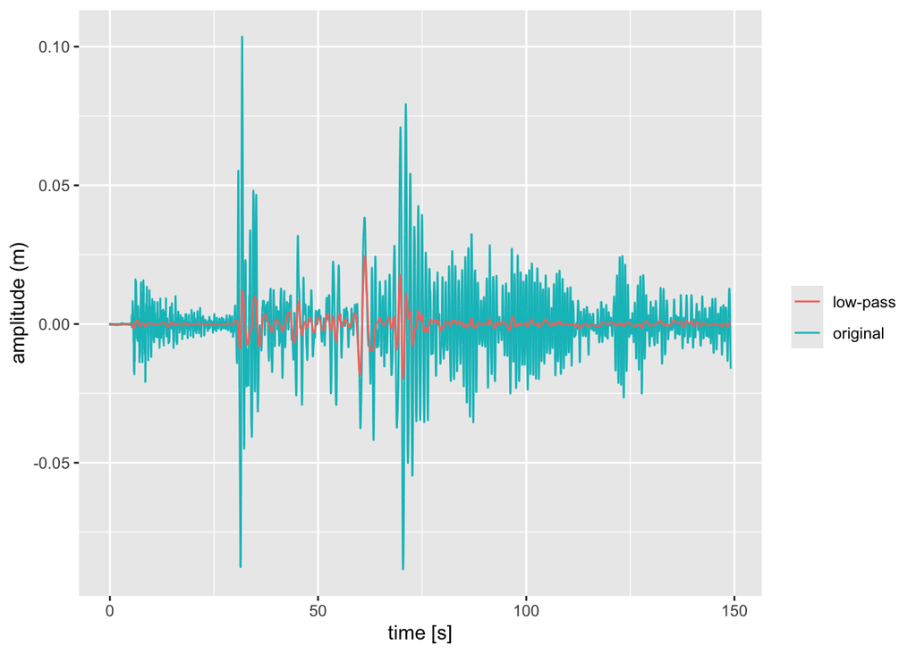

```r
fs <- 1000  # 1 kHz sampling rate
f_nyq <- fs / 2  # Nyquist frequency
f_cutoff <- 1/2  # 2s period

# Create Butterworth filter
butter_low <- butter(2, f_cutoff / f_nyq, type = "low")

# Apply filter
lp <- filtfilt(butter_low, coredata(ts_interp))

ggplot() +
  geom_line(data = data.frame(time = index(ts_interp), ground_motion = coredata(ts_interp)),
           aes(x = time, y = ground_motion, color = 'original')) +
  geom_line(data = data.frame(time = index(ts_interp), ground_motion = lp),
           aes(x = time, y = ground_motion, color = 'low-pass')) +
  labs(x = 'time [s]', y = 'amplitude (m)', color = '')
```

#### High-pass filter

The opposite operation is a **high-pass** filter, which keeps only frequencies higher than a given cutoff. To generate a high-pass filter, you can simply subtract the low-pass filtered version from the original:

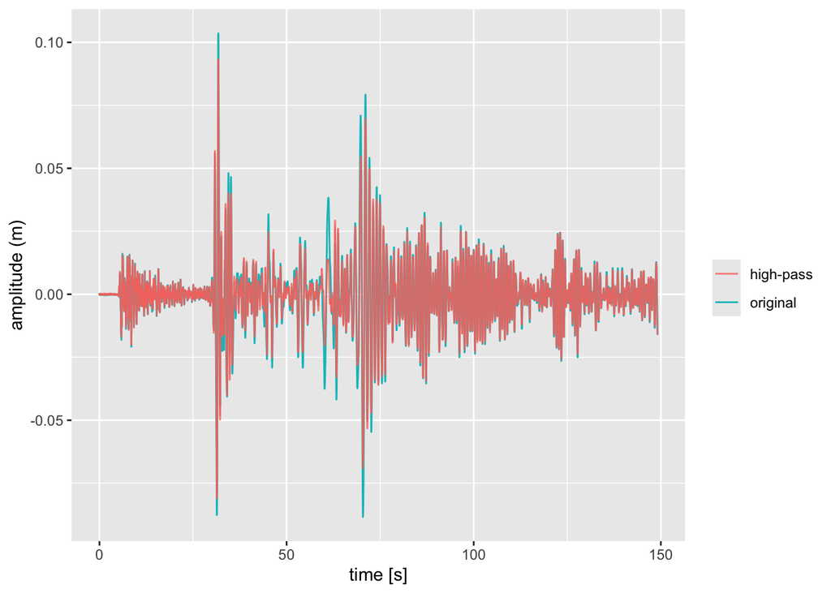

```r
hp <- coredata(ts_interp) - lp

ggplot() +
  geom_line(data = data.frame(time = index(ts_interp), ground_motion = coredata(ts_interp)),
           aes(x = time, y = ground_motion, color = 'original')) +
  geom_line(data = data.frame(time = index(ts_interp), ground_motion = hp),
           aes(x = time, y = ground_motion, color = 'high-pass'), alpha = 0.8) +
  labs(x = 'time [s]', y = 'amplitude (m)', color = '')
```

#### Band-pass filter

If you want to isolate variability in a band of frequencies (say 1-2s), you can create a band-pass filter:

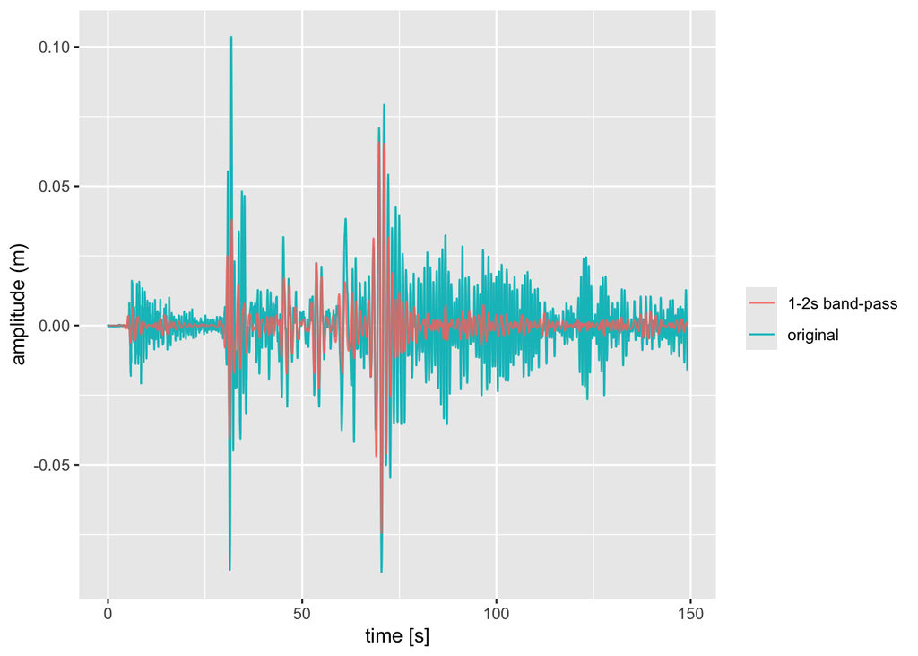

```r
f_low <- 1/2  # 2s period
f_high <- 1/1  # 1s period

butter_band <- butter(2, c(f_low, f_high) / f_nyq, type = "pass")
bp <- filtfilt(butter_band, coredata(ts_interp))

ggplot() +
  geom_line(data = data.frame(time = index(ts_interp), ground_motion = coredata(ts_interp)),
           aes(x = time, y = ground_motion, color = 'original')) +
  geom_line(data = data.frame(time = index(ts_interp), ground_motion = bp),
           aes(x = time, y = ground_motion, color = '1-2s band-pass'), alpha = 0.8) +
  labs(x = 'time [s]', y = 'amplitude (m)', color = '')
```

#### Notch filter

Conversely, if you wanted to remove all variability between 1-2s (a **notch** in frequency space), you would subtract the bandpass-filtered version.

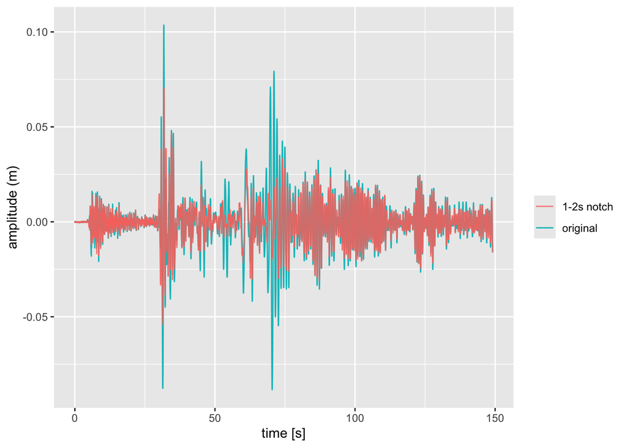

```r
notch <- coredata(ts_interp) - bp

ggplot() +
  geom_line(data = data.frame(time = index(ts_interp), ground_motion = coredata(ts_interp)),
           aes(x = time, y = ground_motion, color = 'original')) +
  geom_line(data = data.frame(time = index(ts_interp), ground_motion = notch),
           aes(x = time, y = ground_motion, color = '1-2s notch'), alpha = 0.8) +
  labs(x = 'time [s]', y = 'amplitude (m)', color = '')
```

## Detrending

Now let’s move on to detrending. We’ll use the HadCRUT5 global mean surface temperature dataset.

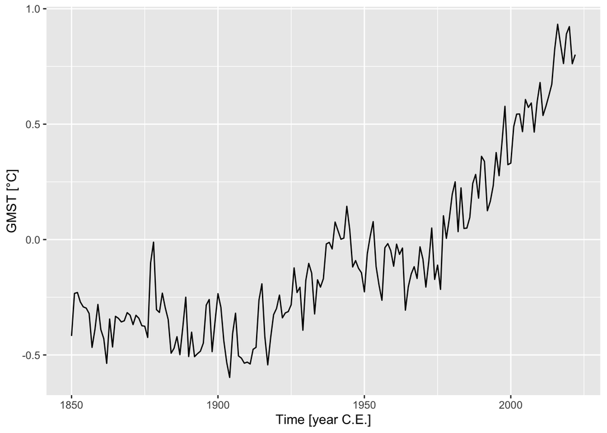

```r
gmst <- read_csv("https://github.com/LinkedEarth/Pyleoclim_util/raw/master/pyleoclim/data/HadCRUT.5.0.1.0.analysis.summary_series.global.annual.csv") %>%
  select(time = Time,temp = `Anomaly (deg C)`)

ggplot(gmst, aes(x = time, y = temp)) +
  geom_line() +
  labs(x = 'Time [year C.E.]', y = 'GMST [°C]')
```

### Detrending methods in R

Let’s apply 3 methods: linear detrending, Empirical Mode Decomposition (EMD), and Savitzky-Golay filter:

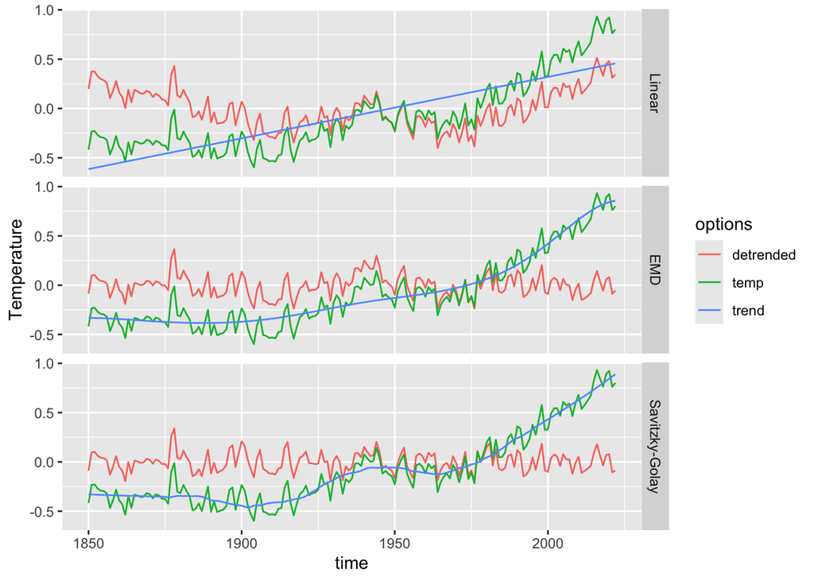

```r
# Linear detrending
gmstLinear <- gmst
gmstLinear$detrended <- pracma::detrend(gmstLinear$temp)
gmstLinear$trend <- gmstLinear$temp - gmstLinear$detrended
gmstLinear$method <- "Linear"


# EMD using the EMD package
library(EMD)
emd_result <- emd(gmst$temp, boundary='symmetric', max.imf=4)

gmstEmd <- gmst
gmstEmd$detrended <- gmst$temp-emd_result$residue
gmstEmd$trend <- gmstEmd$temp - gmstEmd$detrended
gmstEmd$method <- "EMD"

# Savitzky-Golay filter
gmstSg <- gmst
gmstSg$trend <- signal::sgolayfilt(gmst$temp, p = 3, n = 51)
gmstSg$detrended <- gmst$temp - gmstSg$trend
gmstSg$method <- "Savitzky-Golay"

#prepare the data for plotting
gmstToPlot <- dplyr::bind_rows(gmstLinear,gmstEmd,gmstSg) %>%
  tidyr::pivot_longer(cols = -c(time,method),values_to = "Temperature",names_to = "options") %>%
  mutate(method = factor(method,levels = c("Linear","EMD","Savitzky-Golay")))

# Plot it!
ggplot(gmstToPlot) +
  geom_line(aes(x = time, y = Temperature, color = options)) +
  facet_grid(method ~ .)
```

### SSA detrending

Another option to isolate a non-linear trend is Singular Spectrum Analysis (SSA). If there is a prominent trend, it is often the first mode coming out of that analysis.

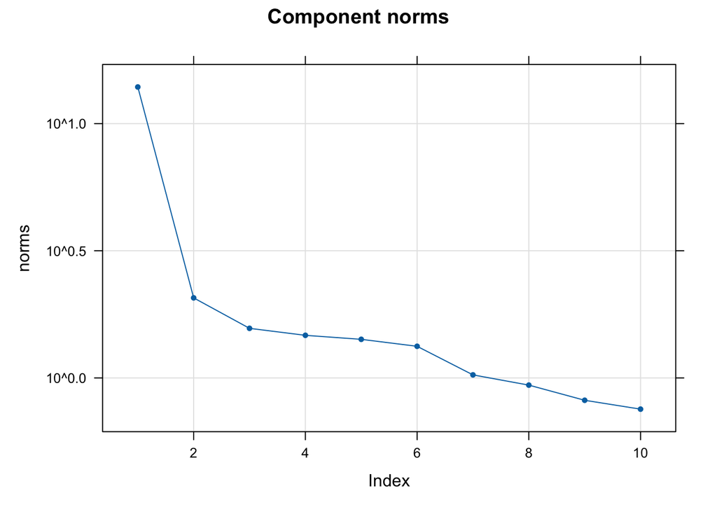

```r
gmst_ssa <- ssa(gmst$temp, L = 10)
plot(gmst_ssa)
```

The first mode accounts for most fraction of the variance. Let’s compute this:

```r
paste0(round(gmst_ssa$sigma[1] / sum(gmst_ssa$sigma),3) * 100,"%")
```

```
## [1] "55%"
```

Let’s use this mode as the trend:

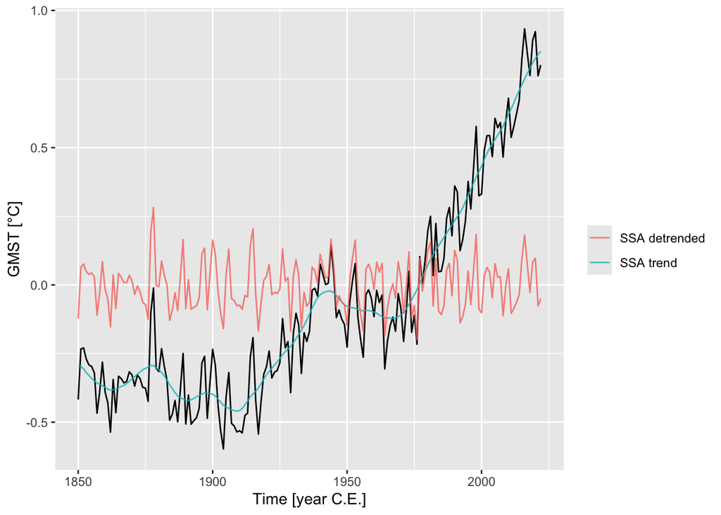

```r
ssa_trend <- reconstruct(gmst_ssa, groups = list(trend = 1))
gmst_ssa_dtd <- data.frame(time = gmst$time, temp = gmst$temp - ssa_trend$trend)

ggplot(gmst, aes(x = time, y = temp)) +
  geom_line() +
  geom_line(aes(y = ssa_trend$trend, color = "SSA trend"), alpha = 0.8) +
  geom_line(aes(y = gmst_ssa_dtd$temp, color = "SSA detrended"), alpha = 0.8) +
  labs(x = 'Time [year C.E.]', y = 'GMST [°C]', color = '')
```

This pre-processing allows us to better isolate oscillatory behavior. To see this, let’s look at the spectra of the original and detrended versions:

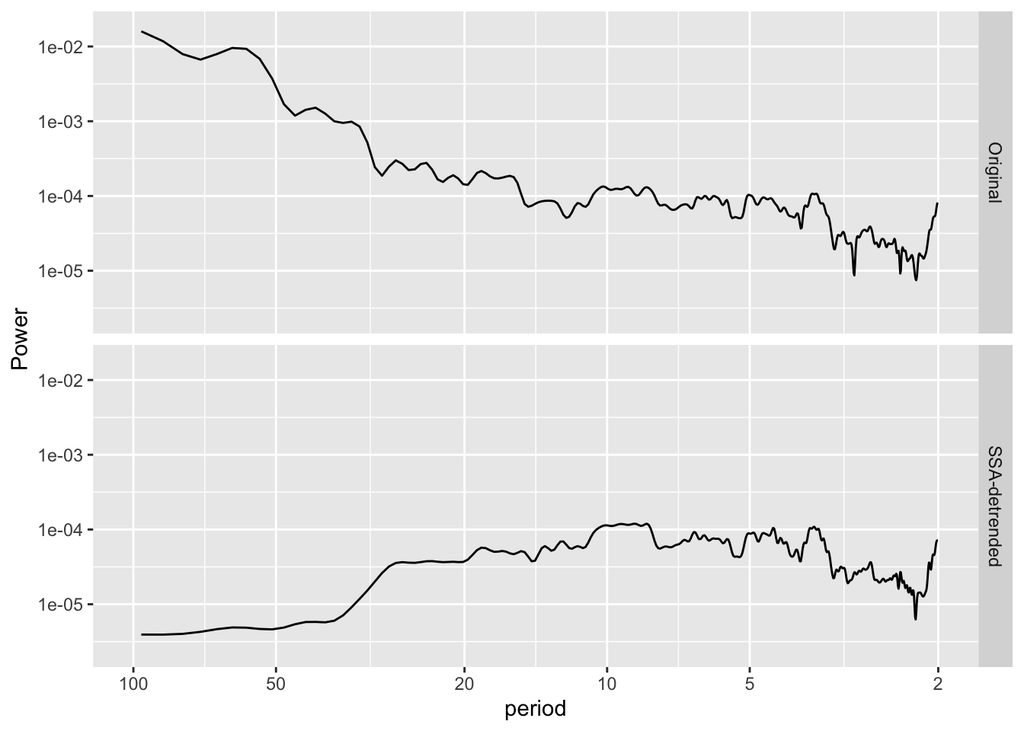

```r
library(astrochron)

mtmOrig <- astrochron::mtm(dat = gmst,output = 1,verbose = F,genplot = F) %>%
  select(Frequency,Power) %>%
  mutate(data = "Original",
         period = (1/Frequency))



mtmSSA <- astrochron::mtm(dat = gmst_ssa_dtd,output = 1,verbose = F,genplot = F) %>%
  select(Frequency,Power) %>%
  mutate(data = "SSA-detrended",
         period = (1/Frequency))

library(scales)
reverselog_trans <- function(base = exp(1)) {
    trans <- function(x) -log(x, base)
    inv <- function(x) base^(-x)
    trans_new(paste0("reverselog-", format(base)), trans, inv,
              log_breaks(base = base),
              domain = c(1e-100, Inf))
}

bind_rows(mtmOrig,mtmSSA) %>%
  ggplot() +
  geom_line(aes(x = period,y = Power)) +
  scale_x_continuous(trans = reverselog_trans(10),breaks = c(100,50,20,10,5,2),limits = c(100,2)) +
  scale_y_log10() +
  facet_grid(data ~ .)
```

We see that detrending has removed much of the variability at scales longer than ~30y, allowing us to hone in on various peaks near 3.5, 6, 10, and 20 years. To see if those are significant, however, you would need to apply a significance test, which we would cover in another tutorial.